# Thesis Validation Overview

Arsalan Anwari

2023-06-16

# 1. Data preparation

## 1.1 Load libraries

```r
options("rgdal_show_exportToProj4_warnings"="none")

library(sf) # used to load maps and manipulate spatial features
library(tidyverse) # used for piping functionality of data manipulation functions
library(gstat) # used for interpolation and validation of idw and kriging models
library(caret) # used for cross validation of other models
library(seewave) # used to calculate surface roughness

library(ggplot2)
library(gridExtra) # to create nxn facets for ggplot

library(conflicted)
conflict_prefer("filter", "dplyr")
conflict_prefer("lag", "dplyr")

source("mqrbf-model-simple.R")
```

## 1.2 Load data

```r
sf_oberservations_train <- readRDS("Data/knmi_windspeed_observations_training_set.rds")
sf_observations_anual <- readRDS("Data/knmi_windspeed_complete_set.rds")
sf_receptors <- readRDS("Data/knmi_windspeed_receptors_training_set.rds")

ls_training_results <- readRDS("Data/dynamic_training_routine_training_results_annual_avg.rds")
ls_training_settings <- readRDS("Data/dynamic_training_routine_training_settings_annual_avg.rds")
```

## 1.3 Prepare data of training set

```r
sf_oberservations_train <- sf_oberservations_train %>%
    mutate(
      x = st_coordinates(.)[,1],
      y = st_coordinates(.)[,2]
    )

df_training_results.trend_surface <- ls_training_results$trend_surface
df_training_results.mqrbf <- ls_training_results$mqrbf
df_training_results.idw <- ls_training_results$idw
df_training_results.od_kriging <- ls_training_results$od_kriging
df_training_results.u_kriging <- ls_training_results$u_kriging
```

```r
head(df_training_results.trend_surface)
```

```
##   model_opt train_iteration         old_rsme         new_rsme
## 1         1               1 13.2644041102413 13.1560285957212
## 2         1               2 13.1560285957212 13.1573733312296
## 3         1               3 13.1573733312296 13.1573710138965
## 4         1               4 13.1573710138965 13.1576166290787
## 5         1               5 13.1576166290787 13.1576164017579
## 6         1               6 13.1576164017579 13.1577119448515
##             loss_value          weights
## 1    0.217114532280504  1.1513017782263
## 2   0.0106280770783336 1.14598773968713
## 3 0.000133950352717613 2.14598773968713
## 4  0.00330331667540569 2.14433608134943
## 5 2.71572152254436e-05 3.14433608134943
## 6  0.00172627739010436 3.14347294265437
```

```r
head(df_training_results.mqrbf)
```

```
##   model_opt train_iteration         old_rsme         new_rsme        loss_value
## 1         1               1 13.4687660716552 13.4213424714382 0.123022501639995
## 2         1               2 13.4213424714382 13.7785278469257 0.492827435166189
## 3         1               3 13.7785278469257 13.9493929258925 0.296884329084741
## 4         1               4 13.9493929258925 16.4368660779041   1.8707366937986
## 5         1               5 16.4368660779041 18.4348180559255  1.60915586863027
## 6         1               6 18.4348180559255 14.1253165799733  2.72931956770368
##             weights
## 1  1.16643465773557
## 2 0.920020940152472
## 3 0.771578775610102
## 4   1.7069471225094
## 5 0.902369188194269
## 6  3.63168875589795
```

```r
head(df_training_results.idw)
```

```
##   model_opt train_iteration         old_rsme         new_rsme
## 1         1               1 14.3056973044216 14.3088168526957
## 2         1               2 14.3088168526957 14.3048234054665
## 3         1               3 14.3048234054665  14.314311195288
## 4         1               4  14.314311195288 14.3057088889954
## 5         1               5 14.3057088889954 14.3218463403827
## 6         1               6 14.3218463403827 14.3093924828195
##           loss_value          weights
## 1 0.0189513047109958  1.0029234794648
## 2 0.0224573482084133 1.02538082767322
## 3 0.0407066240169208 1.00502751566476
## 4 0.0380556824385097 1.04308319810327
## 5 0.0586420462019441  1.0137621750023
## 6 0.0490754479731215 1.06283762297542
```

```r
head(df_training_results.od_kriging)
```

```
##   model_opt train_iteration         old_rsme         new_rsme
## 1         1               1 14.0641701706158 14.0648118489512
## 2         1               2 14.0648118489512  14.064108595096
## 3         1               3  14.064108595096 14.0642161871421
## 4         1               4 14.0642161871421 14.0640106014889
## 5         1               5 14.0640106014889 14.0640401587708
## 6         1               6 14.0640401587708 14.0639556342323
##             loss_value                                                  weights
## 1  0.00639153805981518 0.00471953993229538, 0.471953993229538, 47.1953993229538
## 2  0.00680702120364129 0.00520951449393526, 0.520951449393526, 52.0951449393526
## 3   0.0018731094027437 0.00427295979256341, 0.427295979256341, 42.7295979256341
## 4  0.00292311710399817    0.0044076908807908, 0.44076908807908, 44.076908807908
## 5 0.000770720871974875 0.00402233044480336, 0.402233044480336, 40.2233044480336
## 6   0.0015868425004183 0.00407532652321372, 0.407532652321372, 40.7532652321372
```

```r
head(df_training_results.u_kriging)
```

```
##   model_opt train_iteration         old_rsme         new_rsme
## 1         1               1  15.581034058157 15.5810589150889
## 2         1               2 15.5810589150889 15.5810617160377
## 3         1               3 15.5810617160377 15.5810623571351
## 4         1               4 15.5810623571351 15.5810625913078
## 5         1               5 15.5810625913078 15.5810627087909
## 6         1               6 15.5810627087909 15.5810627820207
##             loss_value
## 1 0.000684225082093577
## 2 0.000152588497708987
## 3 5.53828107942232e-05
## 4 2.77172215150921e-05
## 5 1.72526372794111e-05
## 6 1.24668641305519e-05
##                                                     weights
## 1 0.000286055992770602, 0.286055992770602, 28.6055992770602
## 2 0.000209761743916109, 0.209761743916109, 20.9761743916109
## 3 0.000182070338518997, 0.182070338518997, 18.2070338518997
## 4 0.000168211727761451, 0.168211727761451, 16.8211727761451
## 5 0.000159585409121745, 0.159585409121745, 15.9585409121745
## 6 0.000153351977056469, 0.153351977056469, 15.3351977056469
```

```r
model_opt.trend_surface <- c("model = linear", "model = hyperbolic")
model_opt.mqrbf <- sprintf("smoothing factor = %f", ls_training_settings$mqrbf_smoothing_factor)
model_opt.idw <- sprintf("neighbors = %d", ls_training_settings$neighbor_range)
model_opt.od_kriging <- sprintf("neighbors = %d", ls_training_settings$neighbor_range)
model_opt.u_kriging <- c(
  sprintf("neighbors = %d, model = %s", 5, "linear"),
  sprintf("neighbors = %d, model = %s", 5, "hyperbolic"),
  sprintf("neighbors = %d, model = %s", 6, "linear"),
  sprintf("neighbors = %d, model = %s", 6, "hyperbolic"),
  sprintf("neighbors = %d, model = %s", 7, "linear"),
  sprintf("neighbors = %d, model = %s", 7, "hyperbolic")
)
```

```r
df_training_results.trend_surface <- df_training_results.trend_surface %>%
  rename(model_opt_id = model_opt, old_rmse = old_rsme, new_rmse = new_rsme) %>%
  mutate(
    model_opt_id = as.integer(model_opt_id),
    model_opt_name = model_opt.trend_surface[model_opt_id],
    train_iteration = as.integer(train_iteration),
    old_rmse = as.double(old_rmse),
    new_rmse = as.double(new_rmse),
    loss_value = as.double(loss_value),
    case_weight = as.double(weights)
  ) %>%
  select( model_opt_id, model_opt_name, train_iteration, case_weight, old_rmse, new_rmse, loss_value )

df_training_results.mqrbf <- df_training_results.mqrbf %>%
  rename(model_opt_id = model_opt, old_rmse = old_rsme, new_rmse = new_rsme) %>%
  mutate(
    model_opt_id = as.integer(model_opt_id),
    model_opt_name = model_opt.mqrbf[model_opt_id],
    train_iteration = as.integer(train_iteration),
    old_rmse = as.double(old_rmse),
    new_rmse = as.double(new_rmse),
    loss_value = as.double(loss_value),
    alpha_weight = as.double(weights)
  ) %>%
  select( model_opt_id, model_opt_name, train_iteration, alpha_weight, old_rmse, new_rmse, loss_value )

df_training_results.idw <- df_training_results.idw %>%
  rename(model_opt_id = model_opt, old_rmse = old_rsme, new_rmse = new_rsme) %>%
  mutate(
    model_opt_id = as.integer(model_opt_id),
    model_opt_name = model_opt.idw[model_opt_id],
    train_iteration = as.integer(train_iteration),
    old_rmse = as.double(old_rmse),
    new_rmse = as.double(new_rmse),
    loss_value = as.double(loss_value),
    idp = as.double(weights)
  ) %>%
  select( model_opt_id, model_opt_name, train_iteration, idp, old_rmse, new_rmse, loss_value )

df_training_results.od_kriging <- df_training_results.od_kriging %>%
  rename(model_opt_id = model_opt, old_rmse = old_rsme, new_rmse = new_rsme) %>%
  mutate(
    model_opt_id = as.integer(model_opt_id),
    model_opt_name = model_opt.od_kriging[model_opt_id],
    train_iteration = as.integer(train_iteration),
    old_rmse = as.double(old_rmse),
    new_rmse = as.double(new_rmse),
    loss_value = as.double(loss_value),
    weights = strsplit(weights, ",")
  ) %>%
  unnest_wider(weights, names_sep = "_") %>%
  mutate(
    psill = as.double(weights_2),
    range = as.double(weights_3)
  ) %>%
  select( model_opt_id, model_opt_name, train_iteration, psill, range, old_rmse, new_rmse, loss_value )

df_training_results.u_kriging <- df_training_results.u_kriging %>%
  rename(model_opt_id = model_opt, old_rmse = old_rsme, new_rmse = new_rsme) %>%
  mutate(
    model_opt_id = as.integer(model_opt_id),
    model_opt_name = model_opt.u_kriging[model_opt_id],
    train_iteration = as.integer(train_iteration),
    old_rmse = as.double(old_rmse),
    new_rmse = as.double(new_rmse),
    loss_value = as.double(loss_value),
    weights = strsplit(weights, ",")
  ) %>%
  unnest_wider(weights, names_sep = "_") %>%
  mutate(
    psill = as.double(weights_2),
    range = as.double(weights_3)
  ) %>%
  select( model_opt_id, model_opt_name, train_iteration, psill, range, old_rmse, new_rmse, loss_value )
```

```r
head(df_training_results.trend_surface)
```

```
##   model_opt_id model_opt_name train_iteration case_weight old_rmse new_rmse
## 1            1 model = linear               1    1.151302 13.26440 13.15603
## 2            1 model = linear               2    1.145988 13.15603 13.15737
## 3            1 model = linear               3    2.145988 13.15737 13.15737
## 4            1 model = linear               4    2.144336 13.15737 13.15762
## 5            1 model = linear               5    3.144336 13.15762 13.15762
## 6            1 model = linear               6    3.143473 13.15762 13.15771
##     loss_value
## 1 2.171145e-01
## 2 1.062808e-02
## 3 1.339504e-04
## 4 3.303317e-03
## 5 2.715722e-05
## 6 1.726277e-03
```

```r
head(df_training_results.mqrbf)
```

```
##   model_opt_id               model_opt_name train_iteration alpha_weight
## 1            1 smoothing factor = 12.019620               1    1.1664347
## 2            1 smoothing factor = 12.019620               2    0.9200209
## 3            1 smoothing factor = 12.019620               3    0.7715788
## 4            1 smoothing factor = 12.019620               4    1.7069471
## 5            1 smoothing factor = 12.019620               5    0.9023692
## 6            1 smoothing factor = 12.019620               6    3.6316888
##   old_rmse new_rmse loss_value
## 1 13.46877 13.42134  0.1230225
## 2 13.42134 13.77853  0.4928274
## 3 13.77853 13.94939  0.2968843
## 4 13.94939 16.43687  1.8707367
## 5 16.43687 18.43482  1.6091559
## 6 18.43482 14.12532  2.7293196
```

```r
head(df_training_results.idw)
```

```
##   model_opt_id model_opt_name train_iteration      idp old_rmse new_rmse
## 1            1  neighbors = 5               1 1.002923 14.30570 14.30882
## 2            1  neighbors = 5               2 1.025381 14.30882 14.30482
## 3            1  neighbors = 5               3 1.005028 14.30482 14.31431
## 4            1  neighbors = 5               4 1.043083 14.31431 14.30571
## 5            1  neighbors = 5               5 1.013762 14.30571 14.32185
## 6            1  neighbors = 5               6 1.062838 14.32185 14.30939
##   loss_value
## 1 0.01895130
## 2 0.02245735
## 3 0.04070662
## 4 0.03805568
## 5 0.05864205
## 6 0.04907545
```

```r
head(df_training_results.od_kriging)
```

```
## # A tibble: 6 × 8
##   model_opt_id model_opt_name train_iteration psill range old_rmse new_rmse
##          <int> <chr>                    <int> <dbl> <dbl>    <dbl>    <dbl>
## 1            1 neighbors = 5                1 0.472  47.2     14.1     14.1
## 2            1 neighbors = 5                2 0.521  52.1     14.1     14.1
## 3            1 neighbors = 5                3 0.427  42.7     14.1     14.1
## 4            1 neighbors = 5                4 0.441  44.1     14.1     14.1
## 5            1 neighbors = 5                5 0.402  40.2     14.1     14.1
## 6            1 neighbors = 5                6 0.408  40.8     14.1     14.1
## # ℹ 1 more variable: loss_value <dbl>
```

```r
head(df_training_results.u_kriging)
```

```
## # A tibble: 6 × 8
##   model_opt_id model_opt_name      train_iteration psill range old_rmse new_rmse
##          <int> <chr>                         <int> <dbl> <dbl>    <dbl>    <dbl>
## 1            1 neighbors = 5, mod…               1 0.286  28.6     15.6     15.6
## 2            1 neighbors = 5, mod…               2 0.210  21.0     15.6     15.6
## 3            1 neighbors = 5, mod…               3 0.182  18.2     15.6     15.6
## 4            1 neighbors = 5, mod…               4 0.168  16.8     15.6     15.6
## 5            1 neighbors = 5, mod…               5 0.160  16.0     15.6     15.6
## 6            1 neighbors = 5, mod…               6 0.153  15.3     15.6     15.6
## # ℹ 1 more variable: loss_value <dbl>
```

```r
df_training_results.u_kriging
```

```
## # A tibble: 150 × 8
##    model_opt_id model_opt_name     train_iteration psill range old_rmse new_rmse
##           <int> <chr>                        <int> <dbl> <dbl>    <dbl>    <dbl>
##  1            1 neighbors = 5, mo…               1 0.286  28.6     15.6     15.6
##  2            1 neighbors = 5, mo…               2 0.210  21.0     15.6     15.6
##  3            1 neighbors = 5, mo…               3 0.182  18.2     15.6     15.6
##  4            1 neighbors = 5, mo…               4 0.168  16.8     15.6     15.6
##  5            1 neighbors = 5, mo…               5 0.160  16.0     15.6     15.6
##  6            1 neighbors = 5, mo…               6 0.153  15.3     15.6     15.6
##  7            1 neighbors = 5, mo…               7 0.148  14.8     15.6     15.6
##  8            1 neighbors = 5, mo…               8 0.144  14.4     15.6     15.6
##  9            1 neighbors = 5, mo…               9 0.140  14.0     15.6     15.6
## 10            1 neighbors = 5, mo…              10 0.137  13.7     15.6     15.6
## # ℹ 140 more rows
## # ℹ 1 more variable: loss_value <dbl>
```

# 2. Analyse RMSE results of training set

## 2.1 Find weights with lowest RMSE per model variation for training set

```r
find_lowest_rmse_per_model_opt <- function(df){
  df_grouped_rmse <- df %>%
    group_by(model_opt_id) %>%
    summarise(old_rmse = min(old_rmse))

  df_found <- df %>%
    filter(new_rmse %in% df_grouped_rmse$old_rmse) %>%
    rename(rmse = new_rmse) %>%
    select(!c(model_opt_id, train_iteration, loss_value, old_rmse))

  if (nrow(df_found) == 0){
    df_found <- df %>%
      filter(old_rmse %in% df_grouped_rmse$old_rmse) %>%
      rename(rmse = old_rmse) %>%
      select(!c(model_opt_id, train_iteration, loss_value, new_rmse))
  }

  return(df_found)
}
```

```r
df_lowest_rmse_per_opt.trend_surface <- find_lowest_rmse_per_model_opt(df_training_results.trend_surface)
df_lowest_rmse_per_opt.mqrbf <- find_lowest_rmse_per_model_opt(df_training_results.mqrbf)
df_lowest_rmse_per_opt.idw <- find_lowest_rmse_per_model_opt(df_training_results.idw)
df_lowest_rmse_per_opt.od_kriging <- find_lowest_rmse_per_model_opt(df_training_results.od_kriging)
df_lowest_rmse_per_opt.u_kriging <- find_lowest_rmse_per_model_opt(df_training_results.u_kriging)
```

```r
df_lowest_rmse_per_opt.trend_surface
```

```
##       model_opt_name case_weight     rmse
## 1     model = linear    1.151302 13.15603
## 2 model = hyperbolic    1.000508 13.60280
```

```r
df_lowest_rmse_per_opt.mqrbf
```

```
##                 model_opt_name alpha_weight     rmse
## 1 smoothing factor = 12.019620     1.166435 13.42134
## 2  smoothing factor = 3.004133     1.166435 13.42134
## 3 smoothing factor = 61.296304     1.166434 13.42134
## 4 smoothing factor = 90.770461     1.166434 13.42133
## 5  smoothing factor = 6.502520     1.166435 13.42134
```

```r
df_lowest_rmse_per_opt.idw
```

```
##   model_opt_name      idp     rmse
## 1  neighbors = 5 1.025381 14.30482
## 2  neighbors = 6 1.028791 13.96801
## 3  neighbors = 7 1.015099 14.25143
## 4  neighbors = 8 1.010350 14.26551
```

```r
df_lowest_rmse_per_opt.od_kriging
```

```
## # A tibble: 4 × 4
##   model_opt_name psill range  rmse
##   <chr>          <dbl> <dbl> <dbl>
## 1 neighbors = 5  0.343  34.3  14.1
## 2 neighbors = 6  0.364  36.4  13.7
## 3 neighbors = 7  0.389  38.9  14.2
## 4 neighbors = 8  0.433  43.3  14.3
```

```r
df_lowest_rmse_per_opt.u_kriging
```

```
## # A tibble: 6 × 4
##   model_opt_name                    psill range  rmse
##   <chr>                             <dbl> <dbl> <dbl>
## 1 neighbors = 5, model = linear     0.286  28.6  15.6
## 2 neighbors = 5, model = hyperbolic 0.533  53.3  14.2
## 3 neighbors = 6, model = linear     0.439  43.9  14.3
## 4 neighbors = 6, model = hyperbolic 0.503  50.3  13.7
## 5 neighbors = 7, model = linear     0.438  43.8  15.0
## 6 neighbors = 7, model = hyperbolic 0.498  49.8  14.1
```

## 2.2 Save results of combination of weight and variation with lowest RMSE per model

```r
save.weights_with_lowest_rmse_per_opt <- list(
  trend_surface = df_lowest_rmse_per_opt.trend_surface,
  mqrbf = df_lowest_rmse_per_opt.mqrbf,
  idw = df_lowest_rmse_per_opt.idw,
  od_kriging = df_lowest_rmse_per_opt.od_kriging,
  u_kriging = df_lowest_rmse_per_opt.u_kriging
)

saveRDS(save.weights_with_lowest_rmse_per_opt, "Data/weights_with_lowest_rmse_per_opt.rds")
```

## 2.3 Show fluctuations of new weights and its effect on RMSE

```r
df_training_flucts <- df_training_results.od_kriging %>%
  select(model_opt_id, train_iteration, new_rmse, psill) %>%
  filter(model_opt_id == 2) %>%
  rename(rmse = new_rmse, weight = psill)

df_training_flucts
```

```
## # A tibble: 25 × 4
##    model_opt_id train_iteration  rmse weight
##           <int>           <int> <dbl>  <dbl>
##  1            2               1  13.7  0.475
##  2            2               2  13.7  0.518
##  3            2               3  13.7  0.435
##  4            2               4  13.7  0.447
##  5            2               5  13.7  0.414
##  6            2               6  13.7  0.418
##  7            2               7  13.7  0.401
##  8            2               8  13.7  0.403
##  9            2               9  13.7  0.392
## 10            2              10  13.7  0.394
## # ℹ 15 more rows
```

```r
summary(df_training_flucts$rmse)
```

```
##    Min. 1st Qu.  Median    Mean 3rd Qu.    Max.
##    13.7    13.7    13.7    13.7    13.7    13.7
```

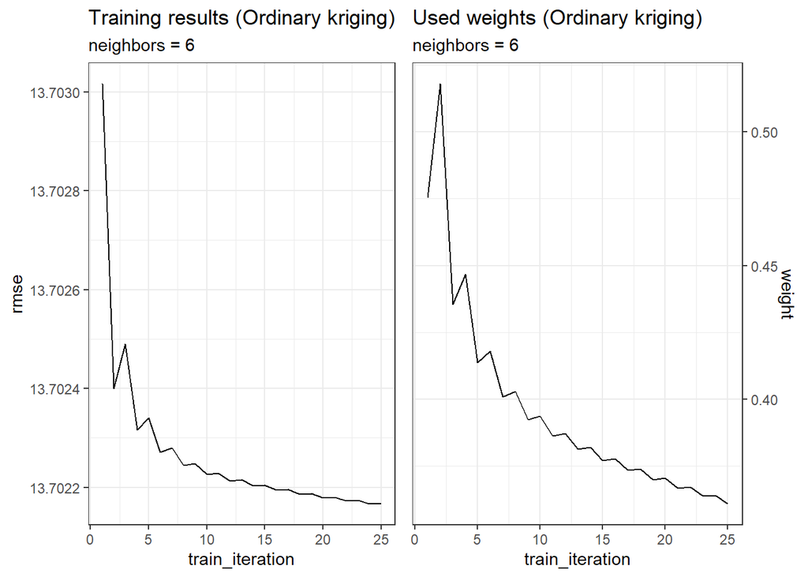

```r
plot_train_results <- df_training_flucts %>%
  ggplot( aes(x = train_iteration, y = rmse) ) +
  geom_line(position = "identity", linewidth = 0.5) +
  scale_fill_grey(start = 0.1, end = 0.9) +
  labs(title = "Training results (Ordinary kriging)", subtitle = "neighbors = 6") +
  theme_bw()

plot_weight_effect <- df_training_flucts %>%
  ggplot( aes(x = train_iteration, y = weight) ) +
  geom_line(position = "identity", linewidth = 0.5) +
  scale_y_continuous(position = "right") +
  scale_fill_grey(start = 0.1, end = 0.9) +
  labs(title = "Used weights (Ordinary kriging)", subtitle = "neighbors = 6") +
  theme_bw()


grid.arrange(plot_train_results, plot_weight_effect, ncol = 2)
```

# 3. Prepare datasets and functions for different metrics

## 3.1 Prepare dataset

### 3.1.1 Seasonal set

```r
season_set_days.spring <- as.Date(c(
  "2017-03-01", "2017-03-08", "2017-03-15", "2017-03-22",
  "2017-04-01", "2017-04-08", "2017-04-15", "2017-04-22",
  "2017-05-01", "2017-05-08", "2017-05-15", "2017-05-22"
))

season_set_days.summer <- as.Date(c(
  "2017-06-01", "2017-06-08", "2017-06-15", "2017-06-22",
  "2017-07-01", "2017-07-08", "2017-07-15", "2017-07-22",
  "2017-08-01", "2017-08-08", "2017-08-15", "2017-08-22"
))

season_set_days.autumn <- as.Date(c(
  "2017-09-01", "2017-09-08", "2017-09-15", "2017-09-22",
  "2017-10-01", "2017-10-08", "2017-10-15", "2017-10-22",
  "2017-11-01", "2017-11-08", "2017-11-15", "2017-11-22"
))

season_set_days.winter <- as.Date(c(
  "2017-12-01", "2017-12-08", "2017-12-15", "2017-12-22",
  "2017-01-01", "2017-01-08", "2017-01-15", "2017-01-22",
  "2017-02-01", "2017-02-08", "2017-02-15", "2017-02-22"
))
```

```r
sf_seasonal_set.spring <- sf_observations_anual %>%
  filter( date %in% season_set_days.spring )

sf_seasonal_set.summer <- sf_observations_anual %>%
  filter( date %in% season_set_days.summer )

sf_seasonal_set.autumn <- sf_observations_anual %>%
  filter( date %in% season_set_days.autumn )

sf_seasonal_set.winter <- sf_observations_anual %>%
  filter( date %in% season_set_days.winter )
```

### 3.1.2 Annual set

```r
gen_annuals_set_days <- function(){
  start_date <- as.Date("2017-01-01")
  out <- rep(NA, times = 48)

  i <- 1
  for(m in 0:11){
    for(d in 0:3){
      new_date <- start_date + months(m) + days(d)
      out[i] <- format(new_date, "%Y-%m-%d")
      i <- i + 1
    }
  }

  return(as.Date(out))
}

annual_set_days <- gen_annuals_set_days()

print(annual_set_days)
```

```
##  [1] "2017-01-01" "2017-01-02" "2017-01-03" "2017-01-04" "2017-02-01"
##  [6] "2017-02-02" "2017-02-03" "2017-02-04" "2017-03-01" "2017-03-02"
## [11] "2017-03-03" "2017-03-04" "2017-04-01" "2017-04-02" "2017-04-03"
## [16] "2017-04-04" "2017-05-01" "2017-05-02" "2017-05-03" "2017-05-04"
## [21] "2017-06-01" "2017-06-02" "2017-06-03" "2017-06-04" "2017-07-01"
## [26] "2017-07-02" "2017-07-03" "2017-07-04" "2017-08-01" "2017-08-02"
## [31] "2017-08-03" "2017-08-04" "2017-09-01" "2017-09-02" "2017-09-03"
## [36] "2017-09-04" "2017-10-01" "2017-10-02" "2017-10-03" "2017-10-04"
## [41] "2017-11-01" "2017-11-02" "2017-11-03" "2017-11-04" "2017-12-01"
## [46] "2017-12-02" "2017-12-03" "2017-12-04"
```

```r
sf_annual_set <- sf_observations_anual %>%
  filter( date %in% annual_set_days )
```

### 3.1.3 Random set

```r
gen_random_set_days <- function(){
  set.seed(54353)

  start_date <- as.Date("2017-01-01")
  out <- rep(NA, times = 48)

  for(i in 1:48){
    rand_day <- as.integer(runif(1, min=6, max=24)) #make sure that no same day as annual set can be picked
    rand_month <- as.integer(runif(1, min=0, max=11))
    new_date <- start_date + months(rand_month) + days(rand_day)

    while(new_date %in% out){
      rand_day <- as.integer(runif(1, min=6, max=24))
      rand_month <- as.integer(runif(1, min=0, max=11))
      new_date <- start_date + months(rand_month) + days(rand_day)
    }

    out[i] <- format(new_date, "%Y-%m-%d")
  }

  return(as.Date(out))
}

random_set_days <- gen_random_set_days()
print(random_set_days)
```

```
##  [1] "2017-05-21" "2017-10-16" "2017-01-22" "2017-10-19" "2017-05-08"
##  [6] "2017-09-08" "2017-02-22" "2017-03-23" "2017-05-09" "2017-04-14"
## [11] "2017-09-10" "2017-07-10" "2017-10-23" "2017-09-17" "2017-06-09"
## [16] "2017-08-10" "2017-11-23" "2017-03-07" "2017-03-20" "2017-01-16"
## [21] "2017-07-15" "2017-04-21" "2017-07-14" "2017-08-12" "2017-11-24"
## [26] "2017-05-07" "2017-02-12" "2017-10-24" "2017-05-10" "2017-08-21"
## [31] "2017-05-18" "2017-05-22" "2017-11-08" "2017-09-16" "2017-06-22"
## [36] "2017-06-19" "2017-02-20" "2017-05-19" "2017-08-20" "2017-08-09"
## [41] "2017-09-12" "2017-05-14" "2017-04-20" "2017-04-07" "2017-05-23"
## [46] "2017-07-11" "2017-05-11" "2017-03-08"
```

```r
sf_random_set <- sf_observations_anual %>%
 filter( date %in% random_set_days )
```

### 3.1.4 Clustered set

```r
sf_sample_map <- sf_observations_anual %>%
  filter( date == as.Date("2017-01-01") )

sf_sample_map
```

```
## Simple feature collection with 44 features and 6 fields
## Geometry type: POINT
## Dimension:     XY
## Bounding box:  xmin: 6075.776 ymin: 324093.6 xmax: 272803.2 ymax: 603272.3
## Projected CRS: Amersfoort / RD New
## First 10 features:
##    station_code       station_name       date windspeed
## 1           209             IJmond 2017-01-01        95
## 2           215        Voorschoten 2017-01-01        50
## 3           225           IJmuiden 2017-01-01        95
## 4           235            De Kooy 2017-01-01        64
## 5           240           Schiphol 2017-01-01        53
## 6           242           Vlieland 2017-01-01        95
## 7           248           Wijdenes 2017-01-01        71
## 8           249           Berkhout 2017-01-01        54
## 9           251 Hoorn Terschelling 2017-01-01        79
## 10          258        Houtribdijk 2017-01-01       100
##                     geometry         x        y
## 1    POINT (95931.09 497827)  95931.09 497827.0
## 2  POINT (89954.25 461848.9)  89954.25 461848.9
## 3  POINT (98442.88 497574.9)  98442.88 497574.9
## 4  POINT (114235.5 549163.1) 114235.45 549163.1
## 5  POINT (114280.3 481284.2) 114280.35 481284.2
## 6    POINT (123874.8 583925) 123874.84 583925.0
## 7  POINT (140566.3 516298.3) 140566.29 516298.3
## 8  POINT (127371.4 517467.6) 127371.42 517467.6
## 9  POINT (152258.4 600630.4) 152258.45 600630.4
## 10 POINT (155933.6 517946.2) 155933.56 517946.2
```

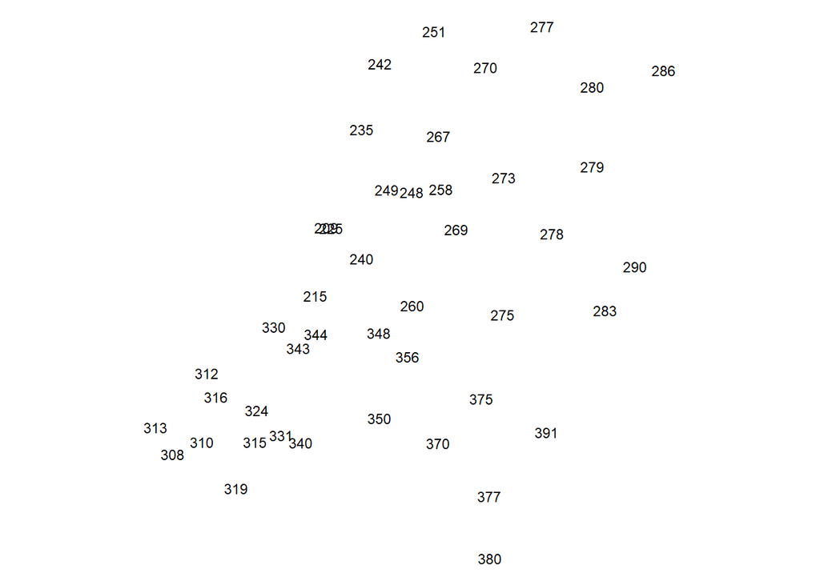

```r
sf_sample_map %>%
  ggplot() +
    geom_sf(alpha = 0.0) +
    geom_sf_text(aes(label = station_code), size = 3) +
    theme_void()
```

As you can see from the plot, the following stations are in or near the province of Zeeland:

```
- 312, 316, 324, 331, 340, 315, 310, 313, 308, 319, 330, 343
```

```r
gen_clustered_set_days <- function(){
  set.seed(35433)

  start_date <- as.Date("2017-01-01")
  out <- rep(NA, times = 48)

  for(i in 1:48){
    rand_day <- as.integer(runif(1, min=0, max=28))
    rand_month <- as.integer(runif(1, min=0, max=11))
    new_date <- start_date + months(rand_month) + days(rand_day)

    while(new_date %in% out){
      rand_day <- as.integer(runif(1, min=6, max=24))
      rand_month <- as.integer(runif(1, min=0, max=11))
      new_date <- start_date + months(rand_month) + days(rand_day)
    }

    out[i] <- format(new_date, "%Y-%m-%d")
  }

  return(as.Date(out))
}

clustered_set_days <- gen_clustered_set_days()
print(clustered_set_days)
```

```
##  [1] "2017-02-11" "2017-09-13" "2017-05-27" "2017-11-10" "2017-03-15"
##  [6] "2017-07-04" "2017-05-09" "2017-01-08" "2017-07-27" "2017-03-22"
## [11] "2017-11-27" "2017-07-23" "2017-11-01" "2017-01-16" "2017-09-19"
## [16] "2017-08-12" "2017-06-20" "2017-03-03" "2017-11-15" "2017-02-12"
## [21] "2017-02-06" "2017-11-05" "2017-08-18" "2017-06-06" "2017-04-20"
## [26] "2017-03-24" "2017-05-16" "2017-08-19" "2017-09-11" "2017-11-23"
## [31] "2017-03-27" "2017-11-19" "2017-02-03" "2017-10-18" "2017-07-25"
## [36] "2017-04-03" "2017-05-08" "2017-01-02" "2017-01-19" "2017-03-17"
## [41] "2017-10-23" "2017-11-17" "2017-06-21" "2017-10-11" "2017-10-02"
## [46] "2017-02-07" "2017-06-17" "2017-05-12"
```

```r
clustered_set_stations <- c(312, 316, 324, 331, 340, 315, 310, 313, 308, 319, 330, 343)

sf_clustered_set <- sf_observations_anual %>%
  filter( date %in% clustered_set_days & station_code %in% clustered_set_stations )
```

### 3.1.5 Sparse set

Based on the map shown in 3.1.4 the following stations where selected from the center and north of the Netherlands for the sparse set:

- Center: 260, 269, 275, 375, 215, 240
- North: 270, 280, 279, 273, 267, 242

The stations 260 and 270 can be seen as the center point where de distance between them and the other points is maximized.

```r
sparse_set_stations <- c(260, 269, 275, 375, 215, 240, 270, 280, 279, 273, 267, 242)

sf_sparse_set <- sf_observations_anual %>%
  filter( date %in% clustered_set_days & station_code %in% sparse_set_stations )
```

### 3.1.6 Check if sets have correct sizes

```r
station_count <- length(unique(sf_observations_anual$station_code))
all_season_set_size <- (
  length(unique(sf_seasonal_set.spring$date)) +
  length(unique(sf_seasonal_set.summer$date)) +
  length(unique(sf_seasonal_set.autumn$date)) +
  length(unique(sf_seasonal_set.winter$date))
)

cat(sprintf(
  "
  Anual set days = %d
  Seasonal set days = %d
    Seasonal days [spring] = %d
    Seasonal days [summer] = %d
    Seasonal days [autumn] = %d
    Seasonal days [winter] = %d
  Random set days = %d
  Clustered set days = %d
  Sparse set days = %d
  ",
  length(unique(sf_annual_set$date)),
  all_season_set_size,
    length(unique(sf_seasonal_set.spring$date)),
    length(unique(sf_seasonal_set.summer$date)),
    length(unique(sf_seasonal_set.autumn$date)),
    length(unique(sf_seasonal_set.winter$date)),
  length(unique(sf_random_set$date)),
  length(unique(sf_clustered_set$date)),
  length(unique(sf_sparse_set$date))
))
```

```
##
##   Anual set days = 48
##   Seasonal set days = 48
##     Seasonal days [spring] = 12
##     Seasonal days [summer] = 12
##     Seasonal days [autumn] = 12
##     Seasonal days [winter] = 12
##   Random set days = 48
##   Clustered set days = 48
##   Sparse set days = 48
##
```

## 3.2 Prepare functions

### 3.2.1 RMSE function

```r
rmse <- function(residuals) {
  return(sqrt(sum((residuals)^2)/length(residuals)))
}
```

### 3.2.2 SLOO-CV functions to calculate rmse

```r
get_rmse.trend_surface <- function(observations, formula){
  if(formula == "windspeed ~ x + y"){
    case_weight <- 1.151302
  } else{
    case_weight <- 1.000508
  }

  model <- train(
    as.formula(formula),
    method = "lm",
    data = observations,
    weights = (1 / windspeed) + case_weight,
    trControl = trainControl(method = "LOOCV")
  )

  residuals <- resid(model)

  return( rmse(residuals) )

}

get_rmse.mqrbf <- function(observations, opts = FALSE){

  model <- mqrbf(
    data = observations,
    alpha_seed = 1.166434,
    smoothing_factor = 90.770461
  )

  resisuals <- train.mqrbf(model)$residuals

  return( rmse(resisuals) )

}

get_rmse.idw <- function(observations, opts = FALSE){

  model <- gstat(
    formula = windspeed ~ 1,
    data = observations,
    nmax = 6,
    set = list(idp = 1.028791)
  )

  { sink(nullfile()); cv <- gstat.cv(model, nfold = nrow(observations), verbose=FALSE); sink(); }

  residuals <- cv$residual

  return( rmse(residuals) )
}

get_rmse.kriging <- function(observations, formula){
  if(formula == "windspeed ~ 1"){
    weight_psill <- 0.3641014
    weight_range <- 36.41014
    vgm_formula <- formula
  } else{
    vgm_formula <- "windspeed ~ x + y"
    if(formula == "windspeed ~ x + y"){
      weight_psill <- 0.4390736
      weight_range <- 43.90736
    } else{
      weight_psill <- 0.5031153
      weight_range <- 50.31153
    }
  }

  kriging.vgm <- variogram(as.formula(vgm_formula), data = observations)
  kriging.vgm.fit <- suppressWarnings(fit.variogram(kriging.vgm, vgm("Sph")))

  base_psill <-  kriging.vgm.fit$psill[1]
  base_range <- kriging.vgm.fit$range[2]
  new_sill <- base_psill + weight_psill
  new_range <- base_range + weight_range

  vgm_model <- suppressWarnings(fit.variogram(
    kriging.vgm,
    vgm(
      psill = new_sill,
      model = "Sph",
      range = new_range
    )
  ))

  model <- suppressWarnings(gstat(
    formula = as.formula(formula),
    data = observations,
    nmax = 6,
    model = vgm_model,
  ))

  { sink(nullfile()); cv <- gstat.cv(model, nfold = nrow(observations), verbose=FALSE); sink(); }

  residuals <- cv$residual

  return( rmse(residuals) )
}
```

### 3.2.3 Prediction funtions to calculate receptor variables

```r
get_preds.trend_surface <- function(observations, formula){
  if(formula == "windspeed ~ x + y"){
    case_weight <- 1.151302
  } else{
    case_weight <- 1.000508
  }

  model <- lm(
    as.formula(formula),
    data = observations,
    weights = (1 / windspeed) + case_weight
  )

  surface <- predict(model, sf_receptors)

  return( surface )
}

get_preds.mqrbf <-  function(observations, opts = FALSE){

  model <- mqrbf(
    data = observations,
    alpha_seed = 1.166434,
    smoothing_factor = 90.770461
  )

  surface <- predict.mqrbf(model, sf_receptors)

  return( surface )

}

get_preds.idw <- function(observations, opts = FALSE){

  sink(nullfile()) # Hide dumb gstat output by forcing all output to a nullfile

  model <- gstat(
    formula = windspeed ~ 1,
    data = observations,
    nmax = 6,
    set = list(idp = 1.028791)
  )

  surface <- predict(model, sf_receptors)$var1.pred

  sink() # Restore output to console

  return(surface)

}

get_preds.kriging <- function(observations, formula){

  if(formula == "windspeed ~ 1"){
    weight_psill <- 0.3641014
    weight_range <- 36.41014
    vgm_formula <- formula
  } else{
    vgm_formula <- "windspeed ~ x + y"
    if(formula == "windspeed ~ x + y"){
      weight_psill <- 0.4390736
      weight_range <- 43.90736
    } else{
      weight_psill <- 0.5031153
      weight_range <- 50.31153
    }
  }

  sink(nullfile()) # Hide dumb gstat output by forcing all output to a nullfile

  kriging.vgm <- variogram(as.formula(vgm_formula), data = observations)
  kriging.vgm.fit <- suppressWarnings(fit.variogram(kriging.vgm, vgm("Sph")))

  base_psill <-  kriging.vgm.fit$psill[1]
  base_range <- kriging.vgm.fit$range[2]
  new_sill <- base_psill + weight_psill
  new_range <- base_range + weight_range

  vgm_model <- suppressWarnings(fit.variogram(
    kriging.vgm,
    vgm(
      psill = new_sill,
      model = "Sph",
      range = new_range
    )
  ))

  model <- suppressWarnings(gstat(
    formula = as.formula(formula),
    data = observations,
    nmax = 6,
    model = vgm_model,
  ))

  surface <- predict(model, sf_receptors)$var1.pred

  sink() # Restore output to console

  return(surface)

}
```

### 3.2.4 Calculate mean RMSE for given model in given time period for any set

```r
calc_mean_rmse <- function(model_rmse_func, model_observations, model_rmse_func_opts){
  model_rmse_results <- c()
  for(filter_date in unique(model_observations$date)){
    observations <- model_observations %>% filter(date == filter_date)
    model_rmse <- model_rmse_func(observations, model_rmse_func_opts)
    model_rmse_results <- append(model_rmse_results, model_rmse)
  }
  return(mean(model_rmse_results))
}
```

### 3.2.5 Calculate max/med/madSR for given model for all days in random set

```r
calc_surface_roughness <- function(model_pred_func, model_observations, model_pred_func_opts){
  model_sr_results <- c()
  for(filter_date in unique(model_observations$date)){
    observations <- model_observations %>% filter(date == filter_date)
    model_pred_result <- model_pred_func(observations, model_pred_func_opts)
    model_pred_result <- model_pred_result / sd(model_observations$windspeed)
    model_sr_result <- roughness(model_pred_result, std = TRUE)
    model_sr_results <- append(model_sr_results, model_sr_result)
  }
  return(list(
    max = max(model_sr_results),
    med = median(model_sr_results),
    mad = mad(model_sr_results)
  ))
}
```

### 3.2.6 Calculate mean surface difference for given model for all days in random set

```r
calc_mean_surface_diff <- function(model_pred_func, model_observations, model_pred_func_opts){
  model_pred_diff_results <- c()
  for(filter_date in unique(model_observations$date)){
    observations <- model_observations %>% filter(date == filter_date)
    model_pred_result <- model_pred_func(observations, model_pred_func_opts)
    model_pred_diff_result <- abs( max(model_pred_result) - min(model_pred_result) )
    model_pred_diff_results <- append(model_pred_diff_results, model_pred_diff_result)
  }
  return(mean(model_pred_diff_results))
}
```

### 3.2.7 Calculate mean surface MAD for given model for all days in random set

```r
calc_mean_surface_mad <- function(model_pred_func, model_observations, model_pred_func_opts){
  model_pred_mad_results <- c()
  for(filter_date in unique(model_observations$date)){
    observations <- model_observations %>% filter(date == filter_date)
    model_pred_result <- model_pred_func(observations, model_pred_func_opts)
    model_pred_mad_result <- mad(model_pred_result)
    model_pred_mad_results <- append(model_pred_mad_results, model_pred_mad_result)
  }
  return(mean(model_pred_mad_results))
}
```

## 3.3 Prepare model data

### 3.3.3 Model Names

```r
model_names <- c(
  "Trend surface (1st order)",
  "Trend surface (3rd order)",
  "MQ-RBF",
  "IDW",
  "Ordinary kriging",
  "Universal kriging (1st order)",
  "Universal kriging (3rd order)"
)
```

### 3.3.4 Regresion polynomial formulas

```r
polynomial_formulas <- c(
  "windspeed ~ 1",
  "windspeed ~ x + y",
  "windspeed ~ x + y + I(x^2) + (x * y) + I(y^2) + I(x^3) + (I(x^2) * y) + (x * I(y^2)) + I(y^3)",
  "windspeed ~ abs(x + y + (x^2) + (x * y) + (y^2) + (x^3) + ((x^2) * y) + (x * (y^2)) + (y^3))"
)
```

# 4. Stability metrics

## 4.1 Seasonal-annual variability

```r
metric.stability.sav <- function(){

  get_model_score <- function(model_name, model_rmse_func, model_rmse_func_opts = FALSE){

    print(sprintf("Calculating score for model %s ....", model_name))
    mean_rmse_annual <- calc_mean_rmse(model_rmse_func, sf_annual_set, model_rmse_func_opts)

    print("Calculating rmse for each season...")
    score <- max(c(
        abs( mean_rmse_annual - calc_mean_rmse(model_rmse_func, sf_seasonal_set.spring, model_rmse_func_opts) ),
        abs( mean_rmse_annual - calc_mean_rmse(model_rmse_func, sf_seasonal_set.summer, model_rmse_func_opts) ),
        abs( mean_rmse_annual - calc_mean_rmse(model_rmse_func, sf_seasonal_set.autumn, model_rmse_func_opts) ),
        abs( mean_rmse_annual - calc_mean_rmse(model_rmse_func, sf_seasonal_set.winter, model_rmse_func_opts) )
    ))

    print(sprintf("Done calculating score!"))
    cat("\r\n")

    return(score)
  }

  scores <-  c(
    get_model_score(model_names[1], get_rmse.trend_surface, polynomial_formulas[2]), # 1st order trend surface
    get_model_score(model_names[2], get_rmse.trend_surface, polynomial_formulas[3]), # 3rd order trend_surface
    get_model_score(model_names[3], get_rmse.mqrbf),
    get_model_score(model_names[4], get_rmse.idw),
    get_model_score(model_names[5], get_rmse.kriging, polynomial_formulas[1]), # ordinary kriging
    get_model_score(model_names[6], get_rmse.kriging, polynomial_formulas[2]), # 1st order universal kriging
    get_model_score(model_names[7], get_rmse.kriging, polynomial_formulas[4]) # 3rd order universal kriging
  )

  return( data.frame(model = model_names, score = scores) )

}
```

```r
results.metric.stability.sav = metric.stability.sav()
```

```
## [1] "Calculating score for model Trend surface (1st order) ...."
## [1] "Calculating rmse for each season..."
## [1] "Done calculating score!"
##
## [1] "Calculating score for model Trend surface (3rd order) ...."
## [1] "Calculating rmse for each season..."
## [1] "Done calculating score!"
##
## [1] "Calculating score for model MQ-RBF ...."
## [1] "Calculating rmse for each season..."
## [1] "Done calculating score!"
##
## [1] "Calculating score for model IDW ...."
```

[output not shown]

```
## [1] "Calculating rmse for each season..."
## [1] "Done calculating score!"
##
## [1] "Calculating score for model Ordinary kriging ...."
## [1] "Calculating rmse for each season..."
## [1] "Done calculating score!"
##
## [1] "Calculating score for model Universal kriging (1st order) ...."
## [1] "Calculating rmse for each season..."
## [1] "Done calculating score!"
##
## [1] "Calculating score for model Universal kriging (3rd order) ...."
## [1] "Calculating rmse for each season..."
## [1] "Done calculating score!"
##
```

```r
results.metric.stability.sav %>% arrange(score)
```

```
##                           model    score
## 1     Trend surface (3rd order) 1.314836
## 2 Universal kriging (3rd order) 1.478996
## 3     Trend surface (1st order) 1.520525
## 4              Ordinary kriging 1.588231
## 5                        MQ-RBF 1.690936
## 6                           IDW 1.708259
## 7 Universal kriging (1st order) 1.761863
```

## 4.2 Seasonal-seasonal variability

```r
metric.stability.ssv <- function(){

  get_model_score <- function(model_name, model_rmse_func, model_rmse_func_opts = FALSE){

    print(sprintf("Calculating score for model %s ....", model_name))

    print("Calculating rmse for each season...")
    scores <- c(
        calc_mean_rmse(model_rmse_func, sf_seasonal_set.spring, model_rmse_func_opts),
        calc_mean_rmse(model_rmse_func, sf_seasonal_set.summer, model_rmse_func_opts),
        calc_mean_rmse(model_rmse_func, sf_seasonal_set.autumn, model_rmse_func_opts),
        calc_mean_rmse(model_rmse_func, sf_seasonal_set.winter, model_rmse_func_opts)
    )

    score <- abs( max(scores) - min(scores) )

    print(sprintf("Done calculating score!"))
    cat("\r\n")

    return(score)
  }

  scores <-  c(
    get_model_score(model_names[1], get_rmse.trend_surface, polynomial_formulas[2]), # 1st order trend surface
    get_model_score(model_names[2], get_rmse.trend_surface, polynomial_formulas[3]), # 3rd order trend_surface
    get_model_score(model_names[3], get_rmse.mqrbf),
    get_model_score(model_names[4], get_rmse.idw),
    get_model_score(model_names[5], get_rmse.kriging, polynomial_formulas[1]), # ordinary kriging
    get_model_score(model_names[6], get_rmse.kriging, polynomial_formulas[2]), # 1st order universal kriging
    get_model_score(model_names[7], get_rmse.kriging, polynomial_formulas[4]) # 3rd order universal kriging
  )

  return( data.frame(model = model_names, score = scores) )

}
```

```r
results.metric.stability.ssv <- metric.stability.ssv()
```

```
## [1] "Calculating score for model Trend surface (1st order) ...."
## [1] "Calculating rmse for each season..."
## [1] "Done calculating score!"
##
## [1] "Calculating score for model Trend surface (3rd order) ...."
## [1] "Calculating rmse for each season..."
## [1] "Done calculating score!"
##
## [1] "Calculating score for model MQ-RBF ...."
## [1] "Calculating rmse for each season..."
## [1] "Done calculating score!"
##
## [1] "Calculating score for model IDW ...."
## [1] "Calculating rmse for each season..."
## [1] "Done calculating score!"
##
## [1] "Calculating score for model Ordinary kriging ...."
## [1] "Calculating rmse for each season..."
## [1] "Done calculating score!"
##
## [1] "Calculating score for model Universal kriging (1st order) ...."
## [1] "Calculating rmse for each season..."
## [1] "Done calculating score!"
##
## [1] "Calculating score for model Universal kriging (3rd order) ...."
## [1] "Calculating rmse for each season..."
## [1] "Done calculating score!"
##
```

```r
results.metric.stability.ssv %>% arrange(score)
```

```
##                           model    score
## 1 Universal kriging (3rd order) 1.871932
## 2     Trend surface (3rd order) 2.102726
## 3                        MQ-RBF 2.158996
## 4              Ordinary kriging 2.204018
## 5     Trend surface (1st order) 2.324046
## 6 Universal kriging (1st order) 2.407070
## 7                           IDW 2.416181
```

## 4.3 Annual random variability

```r
metric.stability.arv <- function(){

  get_model_score <- function(model_name, model_rmse_func, model_rmse_func_opts = FALSE){

    print(sprintf("Calculating score for model %s ....", model_name))

    mean_rmse_annual <- calc_mean_rmse(model_rmse_func, sf_annual_set, model_rmse_func_opts)
    mean_rmse_random <- calc_mean_rmse(model_rmse_func, sf_random_set, model_rmse_func_opts)

    score <- abs(mean_rmse_annual - mean_rmse_random)

    print(sprintf("Done calculating score!"))
    cat("\r\n")

    return(score)
  }

  scores <-  c(
    get_model_score(model_names[1], get_rmse.trend_surface, polynomial_formulas[2]), # 1st order trend surface
    get_model_score(model_names[2], get_rmse.trend_surface, polynomial_formulas[3]), # 3rd order trend_surface
    get_model_score(model_names[3], get_rmse.mqrbf),
    get_model_score(model_names[4], get_rmse.idw),
    get_model_score(model_names[5], get_rmse.kriging, polynomial_formulas[1]), # ordinary kriging
    get_model_score(model_names[6], get_rmse.kriging, polynomial_formulas[2]), # 1st order universal kriging
    get_model_score(model_names[7], get_rmse.kriging, polynomial_formulas[4]) # 3rd order universal kriging
  )

  return( data.frame(model = model_names, score = scores) )

}
```

```r
results.metric.stability.arv <- metric.stability.arv()
```

```
## [1] "Calculating score for model Trend surface (1st order) ...."
## [1] "Done calculating score!"
##
## [1] "Calculating score for model Trend surface (3rd order) ...."
## [1] "Done calculating score!"
##
## [1] "Calculating score for model MQ-RBF ...."
## [1] "Done calculating score!"
##
## [1] "Calculating score for model IDW ...."
## [1] "Done calculating score!"
##
## [1] "Calculating score for model Ordinary kriging ...."
## [1] "Done calculating score!"
##
## [1] "Calculating score for model Universal kriging (1st order) ...."
## [1] "Done calculating score!"
##
## [1] "Calculating score for model Universal kriging (3rd order) ...."
## [1] "Done calculating score!"
##
```

```r
results.metric.stability.arv %>% arrange(score)
```

```
##                           model     score
## 1     Trend surface (1st order) 0.4969291
## 2     Trend surface (3rd order) 0.5005985
## 3              Ordinary kriging 0.6500728
## 4 Universal kriging (3rd order) 0.6724028
## 5                           IDW 0.7787631
## 6                        MQ-RBF 0.7825505
## 7 Universal kriging (1st order) 0.9091394
```

## 4.4 Random-random variability

```r
metric.stability.rrv <- function(){

  get_model_score <- function(model_name, model_rmse_func, model_rmse_func_opts = FALSE){

    print(sprintf("Calculating score for model %s ....", model_name))

    dates <- unique(sf_random_set$date)
    date_chunks <- split(dates, rep(1:4, length.out = length(dates)))
    names(date_chunks) <- paste0("chunk_", 1:4)

    random_set.chunk_1 <- sf_random_set %>% filter(date %in% date_chunks$chunk_1)
    random_set.chunk_2 <- sf_random_set %>% filter(date %in% date_chunks$chunk_2)
    random_set.chunk_3 <- sf_random_set %>% filter(date %in% date_chunks$chunk_3)
    random_set.chunk_4 <- sf_random_set %>% filter(date %in% date_chunks$chunk_4)

    scores <- c(
        calc_mean_rmse(model_rmse_func, random_set.chunk_1, model_rmse_func_opts),
        calc_mean_rmse(model_rmse_func, random_set.chunk_2, model_rmse_func_opts),
        calc_mean_rmse(model_rmse_func, random_set.chunk_3, model_rmse_func_opts),
        calc_mean_rmse(model_rmse_func, random_set.chunk_4, model_rmse_func_opts)
    )

    score <- abs( max(scores) - min(scores) )

    print(sprintf("Done calculating score!"))
    cat("\r\n")

    return(score)
  }

  scores <-  c(
    get_model_score(model_names[1], get_rmse.trend_surface, polynomial_formulas[2]), # 1st order trend surface
    get_model_score(model_names[2], get_rmse.trend_surface, polynomial_formulas[3]), # 3rd order trend_surface
    get_model_score(model_names[3], get_rmse.mqrbf),
    get_model_score(model_names[4], get_rmse.idw),
    get_model_score(model_names[5], get_rmse.kriging, polynomial_formulas[1]), # ordinary kriging
    get_model_score(model_names[6], get_rmse.kriging, polynomial_formulas[2]), # 1st order universal kriging
    get_model_score(model_names[7], get_rmse.kriging, polynomial_formulas[4]) # 3rd order universal kriging
  )

  return( data.frame(model = model_names, score = scores) )

}
```

```r
results.metric.stability.rrv <- metric.stability.rrv()
```

```
## [1] "Calculating score for model Trend surface (1st order) ...."
## [1] "Done calculating score!"
##
## [1] "Calculating score for model Trend surface (3rd order) ...."
## [1] "Done calculating score!"
##
## [1] "Calculating score for model MQ-RBF ...."
## [1] "Done calculating score!"
##
## [1] "Calculating score for model IDW ...."
## [1] "Done calculating score!"
##
## [1] "Calculating score for model Ordinary kriging ...."
## [1] "Done calculating score!"
##
## [1] "Calculating score for model Universal kriging (1st order) ...."
## [1] "Done calculating score!"
##
## [1] "Calculating score for model Universal kriging (3rd order) ...."
## [1] "Done calculating score!"
##
```

```r
results.metric.stability.rrv %>% arrange(score)
```

```
##                           model    score
## 1     Trend surface (3rd order) 1.895224
## 2 Universal kriging (1st order) 2.118617
## 3     Trend surface (1st order) 2.232704
## 4                        MQ-RBF 2.419487
## 5              Ordinary kriging 2.442818
## 6                           IDW 2.496356
## 7 Universal kriging (3rd order) 2.714869
```

## 4.5 Global-local variability

```r
metric.stability.glv <- function(){

  get_model_score <- function(model_name, model_rmse_func, model_rmse_func_opts = FALSE){

    print(sprintf("Calculating score for model %s ....", model_name))

    mean_rmse_clustered <- calc_mean_rmse(model_rmse_func, sf_clustered_set, model_rmse_func_opts)
    mean_rmse_sparse <- calc_mean_rmse(model_rmse_func, sf_sparse_set, model_rmse_func_opts)

    score <- abs(mean_rmse_clustered - mean_rmse_sparse)

    print(sprintf("Done calculating score!"))
    cat("\r\n")

    return(score)
  }

  scores <-  c(
    get_model_score(model_names[1], get_rmse.trend_surface, polynomial_formulas[2]), # 1st order trend surface
    get_model_score(model_names[2], get_rmse.trend_surface, polynomial_formulas[3]), # 3rd order trend_surface
    get_model_score(model_names[3], get_rmse.mqrbf),
    get_model_score(model_names[4], get_rmse.idw),
    get_model_score(model_names[5], get_rmse.kriging, polynomial_formulas[1]), # ordinary kriging
    get_model_score(model_names[6], get_rmse.kriging, polynomial_formulas[2]), # 1st order universal kriging
    get_model_score(model_names[7], get_rmse.kriging, polynomial_formulas[4]) # 3rd order universal kriging
  )

  return( data.frame(model = model_names, score = scores) )

}
```

```r
results.metric.stability.glv <- metric.stability.glv()
```

```
## [1] "Calculating score for model Trend surface (1st order) ...."
## [1] "Done calculating score!"
##
## [1] "Calculating score for model Trend surface (3rd order) ...."
## [1] "Done calculating score!"
##
## [1] "Calculating score for model MQ-RBF ...."
## [1] "Done calculating score!"
##
## [1] "Calculating score for model IDW ...."
## [1] "Done calculating score!"
##
## [1] "Calculating score for model Ordinary kriging ...."
## [1] "Done calculating score!"
##
## [1] "Calculating score for model Universal kriging (1st order) ...."
## [1] "Done calculating score!"
##
## [1] "Calculating score for model Universal kriging (3rd order) ...."
## [1] "Done calculating score!"
##
```

```r
results.metric.stability.glv %>% arrange(score)
```

```
##                           model      score
## 1 Universal kriging (1st order) 0.05937675
## 2                           IDW 0.35496673
## 3     Trend surface (1st order) 0.50039228
## 4              Ordinary kriging 0.81341146
## 5 Universal kriging (3rd order) 0.99438840
## 6     Trend surface (3rd order) 1.35905485
## 7                        MQ-RBF 3.19462947
```

## 4.6 Compare results of all metrics

```r
results.metric.stability.all <- results.metric.stability.sav
colnames(results.metric.stability.all) <- c("model", "sav_score")

results.metric.stability.all$ssv_score <- results.metric.stability.ssv$score
results.metric.stability.all$arv_score <- results.metric.stability.arv$score
results.metric.stability.all$rrv_score <- results.metric.stability.rrv$score
results.metric.stability.all$glv_score <- results.metric.stability.glv$score

results.metric.stability.all
```

```
##                           model sav_score ssv_score arv_score rrv_score
## 1     Trend surface (1st order)  1.520525  2.324046 0.4969291  2.232704
## 2     Trend surface (3rd order)  1.314836  2.102726 0.5005985  1.895224
## 3                        MQ-RBF  1.690936  2.158996 0.7825505  2.419487
## 4                           IDW  1.708259  2.416181 0.7787631  2.496356
## 5              Ordinary kriging  1.588231  2.204018 0.6500728  2.442818
## 6 Universal kriging (1st order)  1.761863  2.407070 0.9091394  2.118617
## 7 Universal kriging (3rd order)  1.478996  1.871932 0.6724028  2.714869
##    glv_score
## 1 0.50039228
## 2 1.35905485
## 3 3.19462947
## 4 0.35496673
## 5 0.81341146
## 6 0.05937675
## 7 0.99438840
```

# 5. Surface metrics

## 5.1 Surface roughness (MaxSR, MedSR and MadSR)

```r
metric.surface.sr <- function(){

  max_sr_results <- c()
  med_sr_results <- c()
  mad_sr_results <- c()

  calc_model_score <- function(model_name, model_pred_func, model_pred_func_opts = FALSE){
    print(sprintf("Calculating surface roughness for model %s ....", model_name))
    results <- calc_surface_roughness(model_pred_func, sf_observations_anual, model_pred_func_opts)

    max_sr_results <<- append(max_sr_results, results$max)
    med_sr_results <<- append(med_sr_results, results$med)
    mad_sr_results <<- append(mad_sr_results, results$mad)

    print(sprintf("Done calculating surface roughness!"))
    cat("\r\n")
  }

  calc_model_score(model_names[1], get_preds.trend_surface, polynomial_formulas[2]) # 1st order trend surface
  calc_model_score(model_names[2], get_preds.trend_surface, polynomial_formulas[3]) # 3rd order trend_surface
  calc_model_score(model_names[3], get_preds.mqrbf)
  calc_model_score(model_names[4], get_preds.idw)
  calc_model_score(model_names[5], get_preds.kriging, polynomial_formulas[1]) # ordinary kriging
  calc_model_score(model_names[6], get_preds.kriging, polynomial_formulas[2]) # 1st order universal kriging
  calc_model_score(model_names[7], get_preds.kriging, polynomial_formulas[4]) # 3rd order universal kriging

  return( data.frame(
    model = model_names,
    max_sr = max_sr_results,
    med_sr = med_sr_results,
    mad_sr = mad_sr_results
  ))

}
```

```r
results.metric.surface.sr <- metric.surface.sr()
```

```
## [1] "Calculating surface roughness for model Trend surface (1st order) ...."
## [1] "Done calculating surface roughness!"
##
## [1] "Calculating surface roughness for model Trend surface (3rd order) ...."
## [1] "Done calculating surface roughness!"
##
## [1] "Calculating surface roughness for model MQ-RBF ...."
## [1] "Done calculating surface roughness!"
##
## [1] "Calculating surface roughness for model IDW ...."
## [1] "Done calculating surface roughness!"
##
## [1] "Calculating surface roughness for model Ordinary kriging ...."
## [1] "Done calculating surface roughness!"
##
## [1] "Calculating surface roughness for model Universal kriging (1st order) ...."
## [1] "Done calculating surface roughness!"
##
## [1] "Calculating surface roughness for model Universal kriging (3rd order) ...."
## [1] "Done calculating surface roughness!"
##
```

```r
results.metric.surface.sr %>% arrange(mad_sr)
```

```
##                           model   max_sr   med_sr   mad_sr
## 1 Universal kriging (3rd order) 27.19476 12.27857 4.746840
## 2              Ordinary kriging 30.48286 13.86663 5.147266
## 3                           IDW 31.03955 13.73423 5.267968
## 4                        MQ-RBF 33.49008 14.31514 5.962057
## 5     Trend surface (3rd order) 38.66137 16.29589 6.266076
## 6 Universal kriging (1st order) 37.53146 17.83328 6.473555
## 7     Trend surface (1st order) 62.68544 22.69222 9.796370
```

## 5.2 Minimum maximum surface deviation

```r
metric.surface.mi_ma_sd <- function(){

  get_model_score <- function(model_name, model_pred_func, model_pred_func_opts = FALSE){
    print(sprintf("Calculating MiMaSD score for model %s ....", model_name))

    score <- calc_mean_surface_diff(model_pred_func, sf_observations_anual, model_pred_func_opts)

    print(sprintf("Done calculating MiMaSD score!"))
    cat("\r\n")

    return(score)
  }

  scores <- c(
    get_model_score(model_names[1], get_preds.trend_surface, polynomial_formulas[2]), # 1st order trend surface
    get_model_score(model_names[2], get_preds.trend_surface, polynomial_formulas[3]), # 3rd order trend_surface
    get_model_score(model_names[3], get_preds.mqrbf),
    get_model_score(model_names[4], get_preds.idw),
    get_model_score(model_names[5], get_preds.kriging, polynomial_formulas[1]), # ordinary kriging
    get_model_score(model_names[6], get_preds.kriging, polynomial_formulas[2]), # 1st order universal kriging
    get_model_score(model_names[7], get_preds.kriging, polynomial_formulas[4]) # 3rd order universal kriging
  )
  return( data.frame(model = model_names, score = scores) )

}
```

```r
results.metric.surface.mi_ma_sd <- metric.surface.mi_ma_sd()
```

```
## [1] "Calculating MiMaSD score for model Trend surface (1st order) ...."
## [1] "Done calculating MiMaSD score!"
##
## [1] "Calculating MiMaSD score for model Trend surface (3rd order) ...."
## [1] "Done calculating MiMaSD score!"
##
## [1] "Calculating MiMaSD score for model MQ-RBF ...."
## [1] "Done calculating MiMaSD score!"
##
## [1] "Calculating MiMaSD score for model IDW ...."
## [1] "Done calculating MiMaSD score!"
##
## [1] "Calculating MiMaSD score for model Ordinary kriging ...."
## [1] "Done calculating MiMaSD score!"
##
## [1] "Calculating MiMaSD score for model Universal kriging (1st order) ...."
## [1] "Done calculating MiMaSD score!"
##
## [1] "Calculating MiMaSD score for model Universal kriging (3rd order) ...."
## [1] "Done calculating MiMaSD score!"
##
```

```r
results.metric.surface.mi_ma_sd %>% arrange(score)
```

```
##                           model    score
## 1                           IDW 48.57091
## 2 Universal kriging (3rd order) 50.85123
## 3     Trend surface (1st order) 50.88872
## 4              Ordinary kriging 53.08012
## 5                        MQ-RBF 53.63380
## 6     Trend surface (3rd order) 54.52495
## 7 Universal kriging (1st order) 57.12196
```

## 5.3 MAD surface deviation

```r
metric.surface.mad_sd <- function(){

  get_model_score <- function(model_name, model_pred_func, model_pred_func_opts = FALSE){
    print(sprintf("Calculating MadSD score for model %s ....", model_name))

    score <- calc_mean_surface_mad(model_pred_func, sf_observations_anual, model_pred_func_opts)

    print(sprintf("Done calculating MadSD score!"))
    cat("\r\n")

    return(score)
  }

  scores <- c(
    get_model_score(model_names[1], get_preds.trend_surface, polynomial_formulas[2]), # 1st order trend surface
    get_model_score(model_names[2], get_preds.trend_surface, polynomial_formulas[3]), # 3rd order trend_surface
    get_model_score(model_names[3], get_preds.mqrbf),
    get_model_score(model_names[4], get_preds.idw),
    get_model_score(model_names[5], get_preds.kriging, polynomial_formulas[1]), # ordinary kriging
    get_model_score(model_names[6], get_preds.kriging, polynomial_formulas[2]), # 1st order universal kriging
    get_model_score(model_names[7], get_preds.kriging, polynomial_formulas[4]) # 3rd order universal kriging
  )
  return( data.frame(model = model_names, score = scores) )

}
```

```r
results.metric.surface.mad_sd <- metric.surface.mad_sd()
```

```
## [1] "Calculating MadSD score for model Trend surface (1st order) ...."
## [1] "Done calculating MadSD score!"
##
## [1] "Calculating MadSD score for model Trend surface (3rd order) ...."
## [1] "Done calculating MadSD score!"
##
## [1] "Calculating MadSD score for model MQ-RBF ...."
## [1] "Done calculating MadSD score!"
##
## [1] "Calculating MadSD score for model IDW ...."
## [1] "Done calculating MadSD score!"
##
## [1] "Calculating MadSD score for model Ordinary kriging ...."
## [1] "Done calculating MadSD score!"
##
## [1] "Calculating MadSD score for model Universal kriging (1st order) ...."
## [1] "Done calculating MadSD score!"
##
## [1] "Calculating MadSD score for model Universal kriging (3rd order) ...."
## [1] "Done calculating MadSD score!"
##
```

```r
results.metric.surface.mad_sd %>% arrange(score)
```

```
##                           model    score
## 1                        MQ-RBF 10.55528
## 2              Ordinary kriging 11.41562
## 3 Universal kriging (1st order) 11.77401
## 4                           IDW 11.98013
## 5 Universal kriging (3rd order) 12.09316
## 6     Trend surface (3rd order) 12.49165
## 7     Trend surface (1st order) 12.91812
```

## 5.4 Compare results of all metrics

```r
results.metric.surface.all <- results.metric.surface.sr

results.metric.surface.all$mi_mad_sd <- results.metric.surface.mi_ma_sd$score
results.metric.surface.all$mad_sd <- results.metric.surface.mad_sd$score

results.metric.surface.all
```

```
##                           model   max_sr   med_sr   mad_sr mi_mad_sd   mad_sd
## 1     Trend surface (1st order) 62.68544 22.69222 9.796370  50.88872 12.91812
## 2     Trend surface (3rd order) 38.66137 16.29589 6.266076  54.52495 12.49165
## 3                        MQ-RBF 33.49008 14.31514 5.962057  53.63380 10.55528
## 4                           IDW 31.03955 13.73423 5.267968  48.57091 11.98013
## 5              Ordinary kriging 30.48286 13.86663 5.147266  53.08012 11.41562
## 6 Universal kriging (1st order) 37.53146 17.83328 6.473555  57.12196 11.77401
## 7 Universal kriging (3rd order) 27.19476 12.27857 4.746840  50.85123 12.09316
```